# Fulmore River Sockeye Salmon Smolt Enumeration

Eric V

2024-08-29

# Project Background

This is document provides a preliminary summary of results from the Fulmore River rotary screw trap program in spring 2024. The Fulmore River is located in the traditional territory of the Tlowitsis First Nation, at the head of Port Neville, approximately 80 NE of Campbell River. The trap was installed on April 11-12, 2024 and fished ~5-days a week (Monday to Friday) until May 31, 2024. All fish captured in the trap were identified to species and measured for fork length. Biological samples were collected from a subset of fish each day. Releases of marked fish occurred weekly to assess trap efficiency, however, no estimate of capture efficiency is presented as smolts did not take to Bismark (would not dye) and captures were too low to effectively mark with fin clip.

## Captures to Date

Since April 15, the trap has fished for a total of 21 days, resulting in the capture of Sockeye Salmon, Coho Salmon, one Chum Salmon, Coastal Cutthroat Trout, Dolly Varden Char, Pacific Lamprey, Sculpin (Cottidae spp.) and sticklebacks.

Summary of total number and biological data collected of fish captured since April 15, 2024.

[output not shown]

The greatest number of catches occurred during the first two days of trap operation when 392 Sockeye Salmon were captured (53% of total catch of Sockeye Salmon). The relatively lack of fish captured during subsequent days and weeks suggests that sampling occurred during the tail end of the migration period.

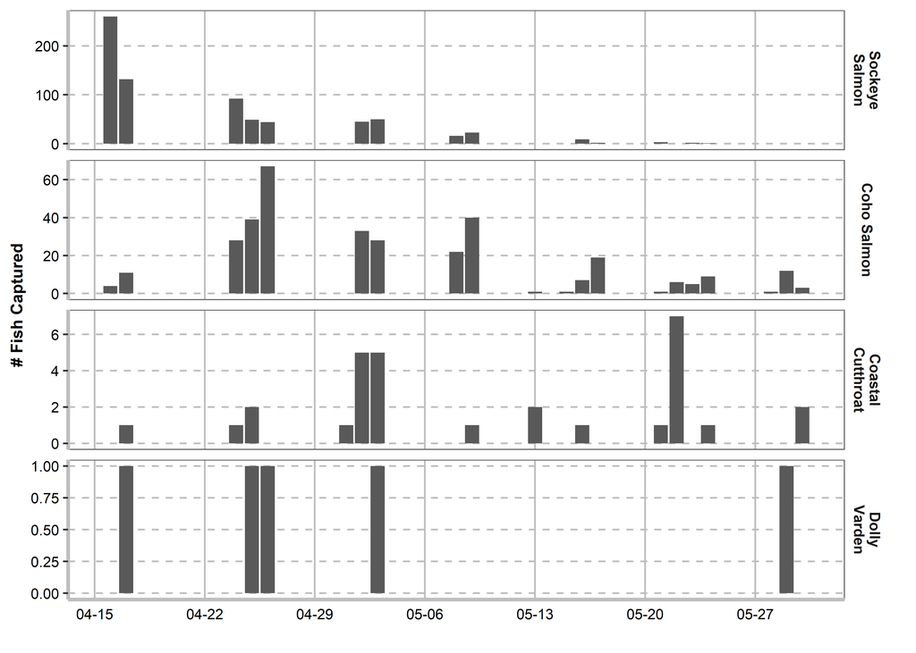

Figure 1: Number of Sockeye Salmon, Coho Salmon, Coastal Cutthroat Trout, and Dolly Varden Char captured per day of sampling.

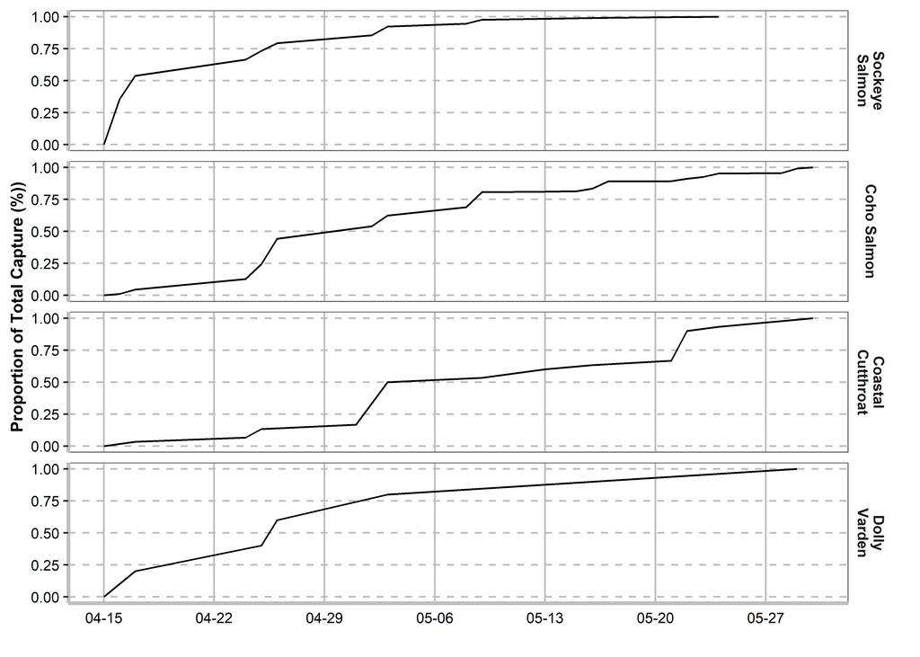

Figure 2: Proportion of total capture by date.

# Sockeye Salmon

The length-frequency distribution for Sockeye Salmon smolts is multimodal, indicating at least two groups of different sized fish were emigrating simultaneously. Most likely, this difference in size is due the presence of multiple age classes of smolts, which will be confirmed once scale aging is complete.

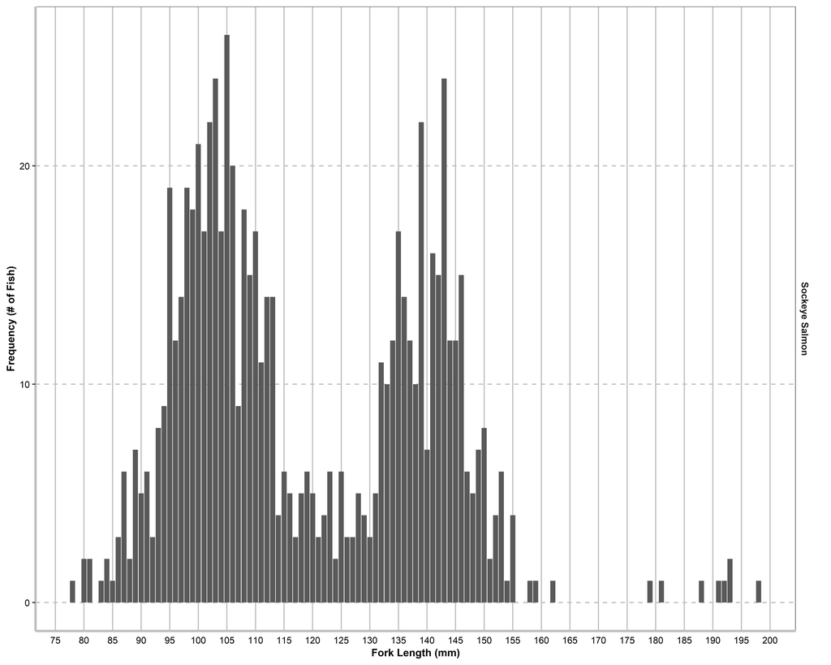

Figure 3: Length frequency plot of Sockeye Salmon captured in the Fulmore River.

**Estimated Size of Age-1, Age-2 and Age-3 Sockeye Salmon captured in the Fulmore River in spring 2024.**

| Age Class | n | Prop (%) | Fork Length n | Fork Length Mean | Fork Length SE | Fork Length Min | Fork Length Max | Weight (g) n | Weight (g) Mean | Weight (g) SE | Weight (g) Min | Weight (g) Max |
| --- | --- | --- | --- | --- | --- | --- | --- | --- | --- | --- | --- | --- |
| Age-1 | 419 | 57.7 | 419 | 102.7 | 0.4 | 78 | 120 | 387 | 9.8 | 0.1 | 4.2 | 16.5 |
| Age-2 | 299 | 41.2 | 299 | 139.2 | 0.5 | 121 | 162 | 285 | 23.8 | 0.2 | 10.3 | 35.0 |
| Age-3 | 8 | 1.1 | 8 | 189.4 | 2.3 | 179 | 198 | 8 | 28.8 | 3.1 | 23.1 | 50.1 |

### Data Exploration

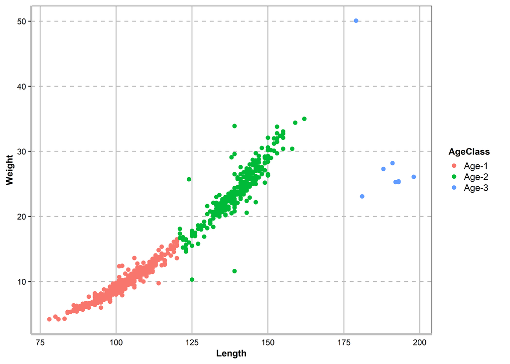

Figure 4: Fork length and weight of Sockeye Salmon captured in the Fulmore River.

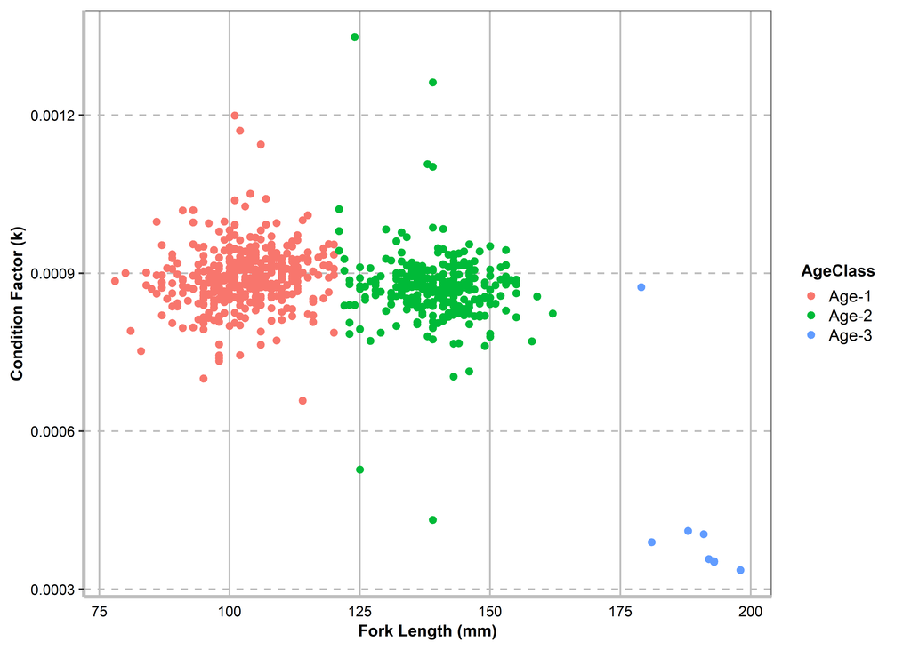

Figure 5: Fork length and condition factor (k) of Sockeye Salmon captured in the Fulmore River.

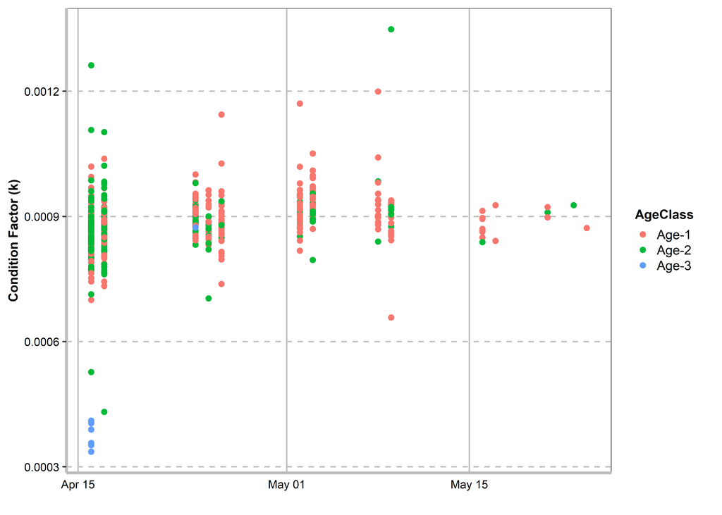

Figure 6: Condition Factor (k) of Sockeye Salmon over time in the Fulmore River.

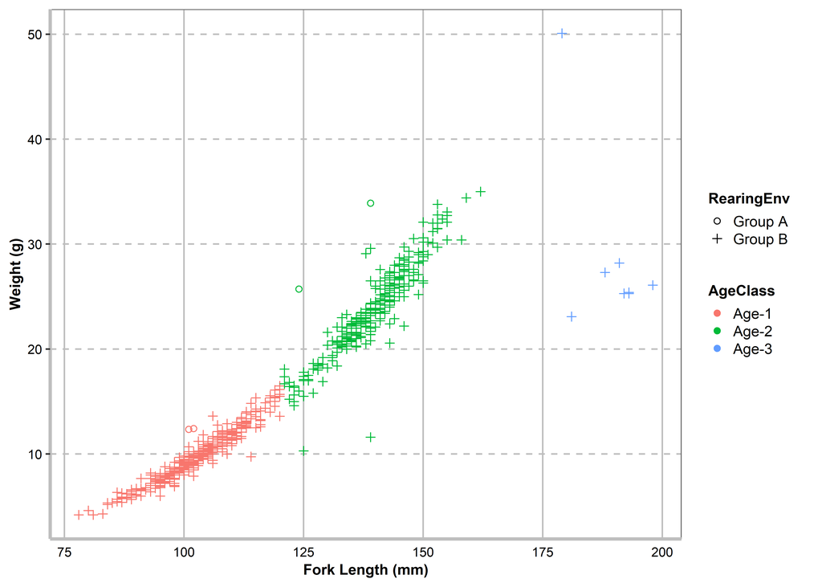

Figure 7: Fork length and weight of Sockeye Salmon captured in the Fulmore River, with emphasis on condition factor.

The data suggests there is a physiological difference among smolts in terms of size and condition at age. Though not definitive, differences in behaviour would also be an indication that that there may be environmental or behavioural factors influencing observed differences in condition. To see if there is evidence for a behavioural difference between groups we can re-plot the length-frequency figure to show the number of fish from each group that were captured per week of trapping and look at the total number of fish from each group originating from each group.

[figure not shown]

Figure 8: Length-Frequency plot showing number of Sockeye Salmon captured per week from Group A (better condition) and Group B (poorer condition).

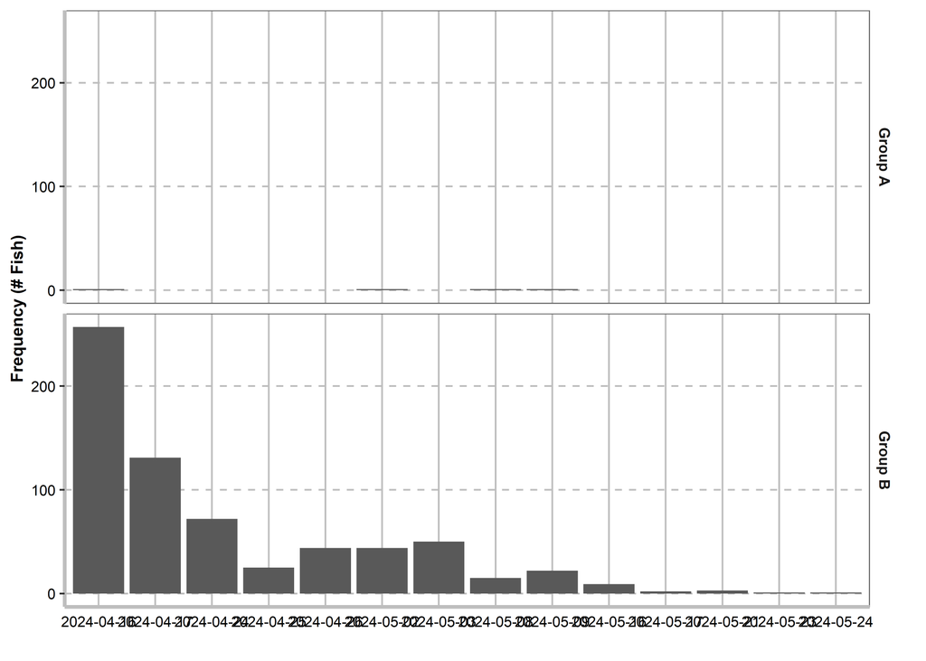

### Sockeye Salmon Data Summary

# Coho Salmon

The length-frequency plot for Coho Salmon also shows two distinct age classes; Coho Salmon fry were ~30-65 mm while parr were ~85 to 145 mm. Coho Salmon fry may have been moving to the estuary or to more downstream freshwater rearing habitats, while parr are almost certainly migrating towards the sea. Similar to the length weight plot for Sockeye there appears to be a subset of Coho Salmon that are relatively poorer condition, though the majority appear to be of similar condition.

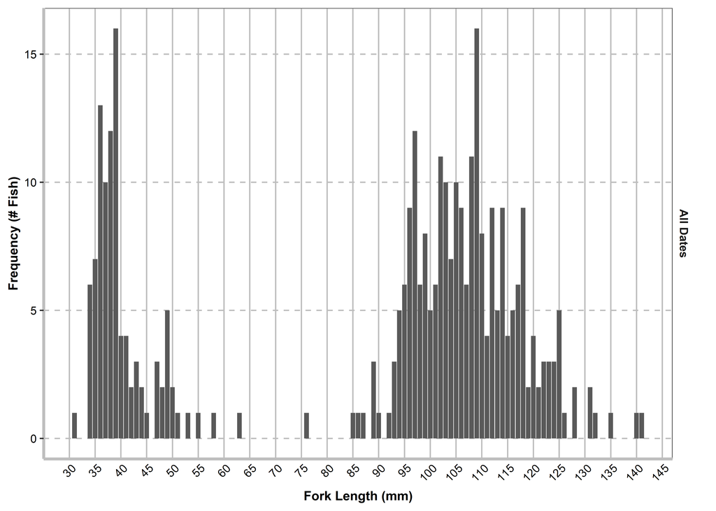

Figure 9: Length-frequency distribution for all Coho Salmon captured in the Fulmore River.

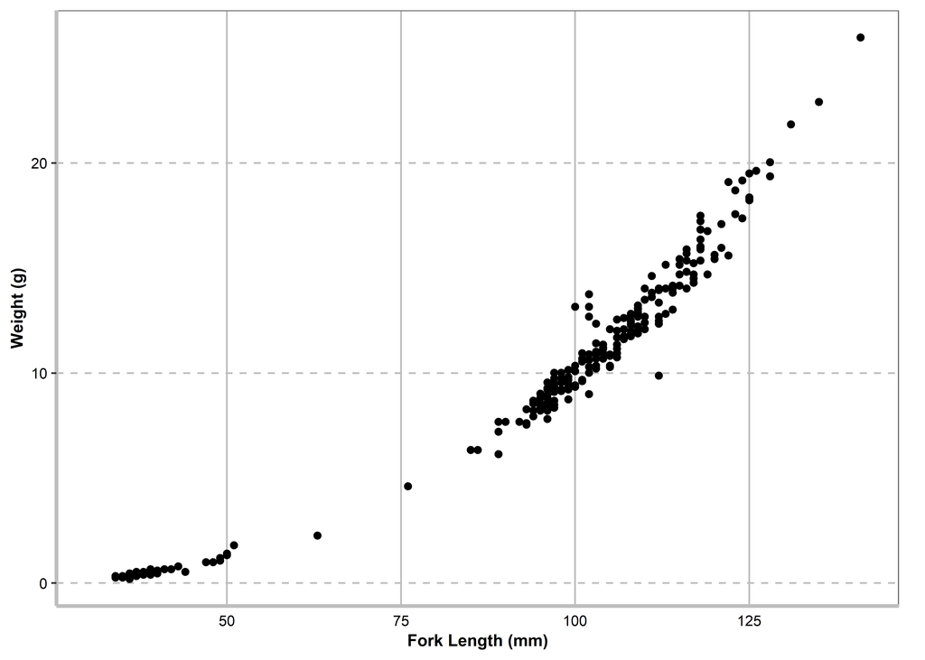

Figure 10: Length and weight of Coho Salmon captured in the Fulmore River.